# Intro to Data Visualization in R

2025-08-12

## Why Visualize

- See patterns, spot anomalies, generate questions. The purpose is to literally *see* what your data seems to say.
- Communicate findings clearly and persuasively.
- Start simple: summaries + visuals. (EDA mindset)
- Human brains are very good at identifying complex patterns … and similarly they can easily be fooled!

> *“The simple graph has brought more information to the data analyst’s mind than any other device.” — John Tukey*

## What is EDA?

- Exploratory data analysis (EDA) is the first step in **understanding** the main features and structures of a data set.
- Many statistical tools and techniques are used when performing EDA, but crucially they are **simple** to allow the data **speak** for itself.
- Tools that a data scientist may use are:
  - Data transformation/wrangling
  - Calculation of simple summary statistics (mean, median, variance, correlation, etc.)
  - Tabulation, Graphical or visual representations

> *“Although we often hear that data speak for themselves, their voices can be soft and sly.” — Mosteller et al. (1983)*

## ggplot2 \(\in\) tidyverse

- The most widely used R package for graphics.

[figure not shown]

- **ggplot2** is tidyverse’s data visualization package
- `gg` in “ggplot2” stands for *Grammar of Graphics* from the book by Leland Wilkinson

## Main layers of the grammer


## Structure of creating a plot

- `ggplot()` is the main function in ggplot2
- Construct plots by *adding* (`+`) layers – **Not** the `%>%` pipe!
- Many types of geometries:
  - `geom_points()`, `geom_histogram()`, `geom_line()`, `geom_boxplot()`, etc.
- [ggplot2 cheat sheet](https://www.rstudio.com/resources/cheatsheets/)

## General Usage

```r
ggplot(data = [dataset], # Data
       # Aesthetics
       mapping = aes(x = [x-variable], y = [y-variable])) +
  # Geometries
   geom_[*]() +
  # ...
   other options
```

## Example: Palmer Penguins

Measurements for penguin species, island in Palmer Archipelago, size (flipper length, body mass, bill dimensions), and sex.

```
## Rows: 344
## Columns: 8
## $ species           <fct> Adelie, Adelie, Adelie, Adelie, Adelie, Adelie, Adel…
## $ island            <fct> Torgersen, Torgersen, Torgersen, Torgersen, Torgerse…
## $ bill_length_mm    <dbl> 39.1, 39.5, 40.3, NA, 36.7, 39.3, 38.9, 39.2, 34.1, …
## $ bill_depth_mm     <dbl> 18.7, 17.4, 18.0, NA, 19.3, 20.6, 17.8, 19.6, 18.1, …
## $ flipper_length_mm <int> 181, 186, 195, NA, 193, 190, 181, 195, 193, 190, 186…
## $ body_mass_g       <int> 3750, 3800, 3250, NA, 3450, 3650, 3625, 4675, 3475, …
## $ sex               <fct> male, female, female, NA, female, male, female, male…
## $ year              <int> 2007, 2007, 2007, 2007, 2007, 2007, 2007, 2007, 2007…
```

## Example: Penguins dataset

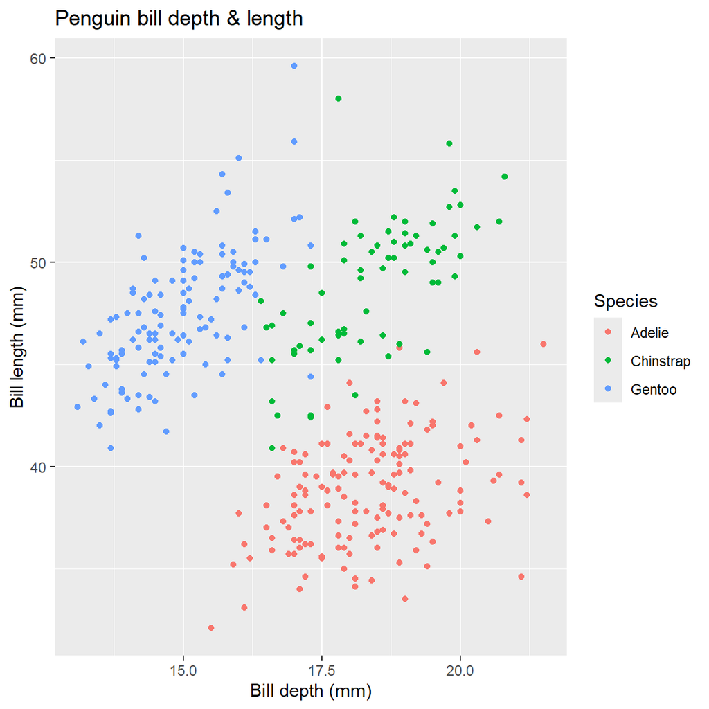

## Example: Penguins dataset

```r
penguins <- palmerpenguins::penguins
ggplot(data = penguins,
       mapping = aes(x = bill_depth_mm, y = bill_length_mm,
                     colour = species)) +
  geom_point() +
  labs(title = "Penguin bill depth & length",
       x = "Bill depth (mm)",
       y = "Bill length (mm)",
       colour = "Species")
```

## And iterate …

- Editing the aesthetic options: Point colour, size, shape, etc.
- Incorporate more variables from the data set.
- Specify the limits of the co-ordinate axes to zoom in or out.
- Include additional descriptive information: sub-title, caption, data source citation, etc.
- Add other graphical information: line/curve of best fit, arrows, estimation intervals, etc.
- Faceting/panelling multiple plots into a grid.
- Changing the colour pallet that is more accessible for colour blindness.
- …

**However**, more is not necessarily good - there should be certain design choices

## Understanding your data

- There are many types of data visualisation, each designed with a particular purpose.
- To determine which visualisation style is appropriate, consider:
  1. What are the properties of variables?
  2. How many variables to include in the data visualisation?
  3. What aspect of the data do you want to explore, investigate and communicate?

## Types of variables

- **Quantitative variables** are variables whose data are numerical values.
  - **Discrete variables** describes count data, typically non-negative integer values.  
    Eg, Number of IDS students or number of election votes.
  - **Continuous variables** are typically real-valued measurements, rounded to a specified number of decimal places or significant figures.  
    Eg, Penguin bill length, body mass and flipper length.

## Types of variables

- **Qualitative variable** are variables that are descriptive.
  - **Categorical (factor) variables** usually identify one option from a small set of cases.  
    Eg, Penguin breeds (Adelie, Chinstrap or Gentoo).
  - **Ordinal variables** are categorical variables that have a natural ordering.  
    Degree grades: First, upper-second, lower-second and third.

[From Data to Viz](https://www.data-to-viz.com/)

## Number of variables involved

- One variable (Univariate data analysis)
  - What is the *location*, *spread* and *shape* of the data?
  - Types of visualisations:**histogram**, **box plot**, **bar chart**, etc.
- Two variables (Bivariate data analysis)
  - Investigating the relationship between two variables. Positive/negative correlation? Linear or non-linear relationship?
  - Types of visualisations: **scatter plot**, **box plots**, **segmented bar plot**, etc.
- Three or more variables (Multivariate data analysis)
  - Investigating the relationship between many variables simultaneously.
  - Use of **colour**, **style** and **faceting** - be creative!

## Motivating Data Set: Bats

- Extracted from the [Atlantic Mammal Traits](https://esajournals.onlinelibrary.wiley.com/doi/10.1002/ecy.2106) survey on animal morphology.
- Data contains information about 4334 Neotropical fruit bats (*Aribeus*) from South America between 2010-2017.

```
## Rows: 4,334
## Columns: 6
## $ species   <chr> "Artibeus cinereus", "Artibeus cinereus", "Artibeus cinereus…
## $ body_mass <dbl> 12, 13, 11, 8, 13, 19, 12, 16, 11, 15, 18, 11, 11, 12, 14, 1…
## $ forearm   <dbl> 41.0, 38.6, 39.1, 39.2, 39.0, 43.0, 40.0, 41.0, 41.0, 40.5, …
## $ age       <chr> "adult", "adult", "adult", "adult", "adult", "adult", "juven…
## $ sex       <chr> "male", "female", "male", "male", "male", "female", "male", …
## $ year      <dbl> 2011, 2011, 2011, 2011, 2011, 2011, 2011, 2011, 2011, 2011, …
```

## Data Dictionary

| Variable | Description | Type |
| --- | --- | --- |
| `species` | Name of bat species | Categorical (5 cases) |
| `body_mass` | Body mass (in grams) | Numerical, continuous |
| `forearm` | Forearm length (in mm) | Numerical, continuous |
| `age` | Adult or Juvenile | Categorical (2 cases) |
| `sex` | Female or Male | Categorical (2 cases) |
| `year` | Year of measurement | Numerical, discrete |

## Histogram by default

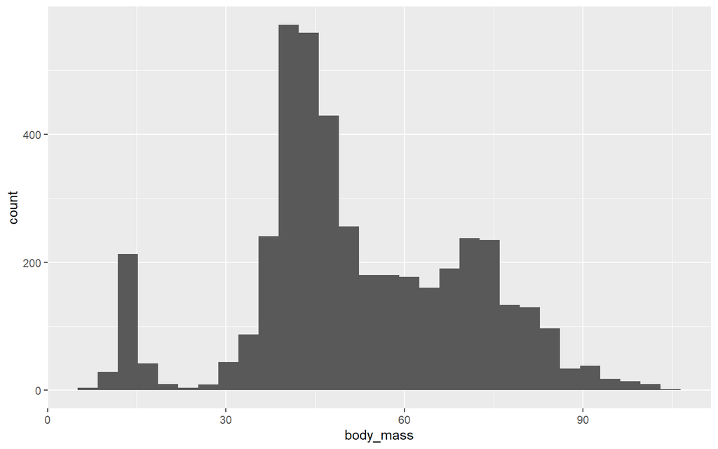

## Histogram by certain modifications

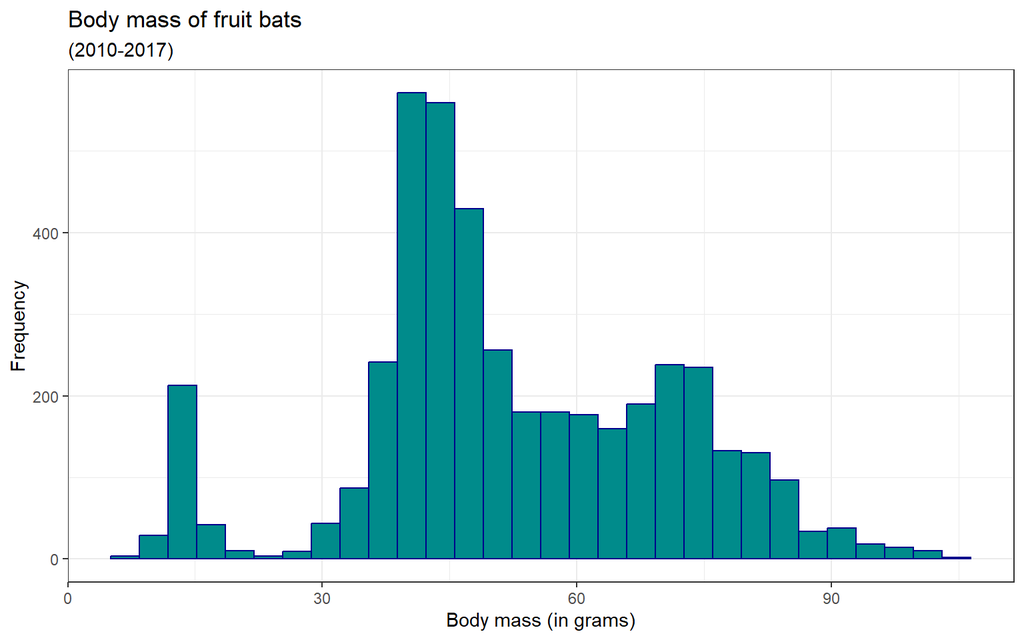

## Density plot

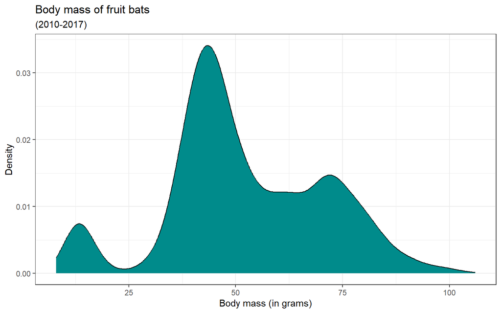

## Box plot

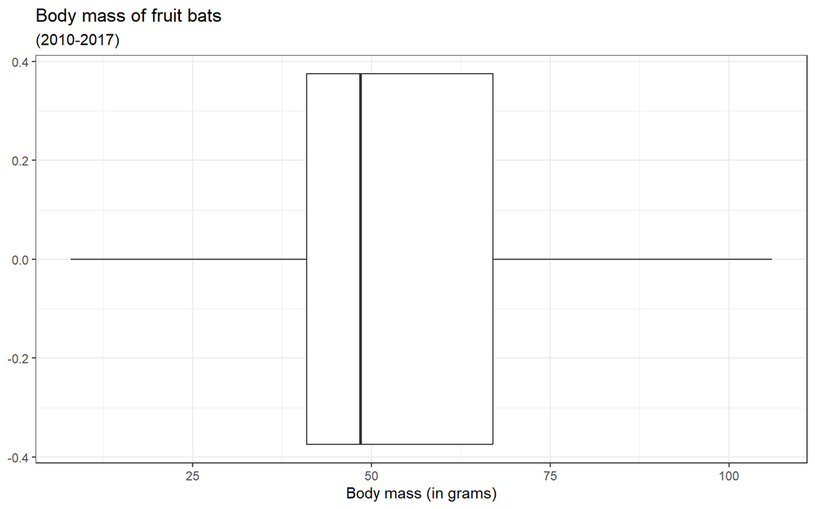

## Adding a categorical variable via aesthetics

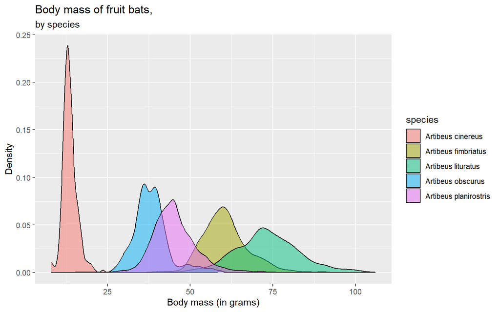

## Via facetings

As a 2x2 setting

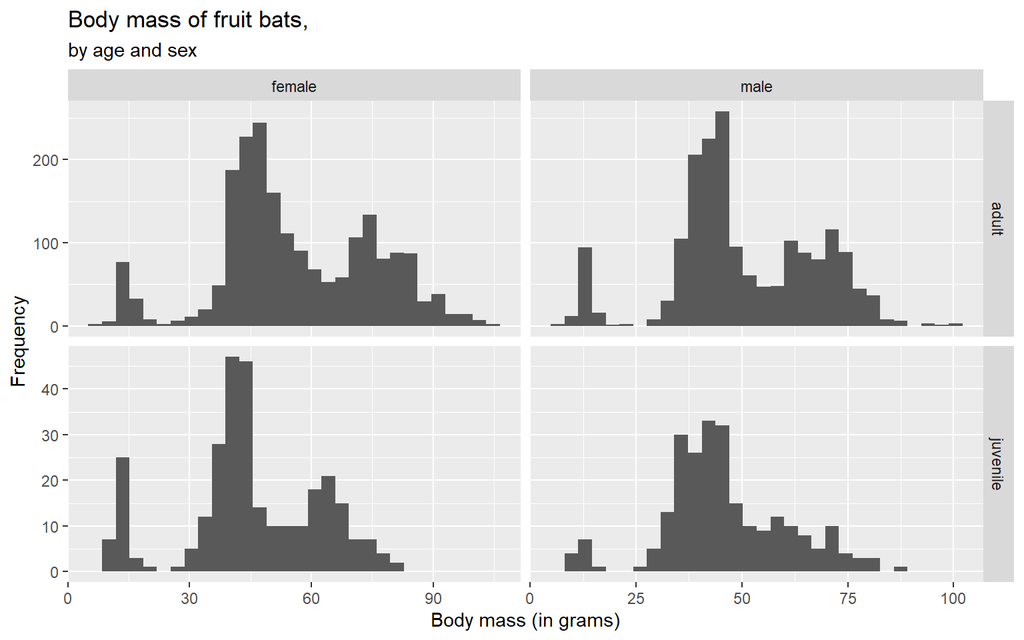

## Data visualisation gallery

- `ggplot2` is used to create a wide variety of data visualisation styles. It has many customisation tools to support your communication.
- Use `ggplot2` manual pages (and online searches) to support your creation.
- Specific starting point would be [R Graph gallery](https://r-graph-gallery.com/)
- **But**, excessive customisation can be distracting.
- Remember the 4 respects: 1. Respect the **people**, 2. Respect the **data**, 3. Respect the **mathematics** and 4. Respect the **computers**

## RSS: Best Practices for Data Visualisation

- **[Best Practices for Data Visualisation](https://royal-statistical-society.github.io/datavisguide/)** aims to equip readers with the fundamentals for creating data visualizations that are high-quality, readable, impactful, and accurate in both presentation and interpretation.
- The guide blends both the scientific and creative aspects of visualization — it emphasizes that data viz is not just plotting defaults, but actively telling a story and choosing design elements deliberately to serve that story
- Though primarily aimed at RSS publications (Significance magazine, JRSS Series A, Real World Data Science), the guidance is broadly relevant for any data viz task

*Thanks to Andreas Krause, Nicola Rennie, and Brian Tarran*

## Principles & Choosing Chart Types

To select the right chart type, consider:

1. **Data type** (e.g., numeric, categorical) — tools like *From Data to Viz* use decision trees to suggest suitable chart formats.
2. **Data relationship** (e.g., correlation, ranking, deviation) — platforms like *Visual Vocabulary* guide selection based on the main relationship you want to show

Checklist:

- Be clear on the visualization’s purpose.
- Know your audience.
- Choose chart type based on data structure or relationship.
- Refine with audience’s graph literacy in mind

## Styling & Accessibility

Emphasis is placed on styling for **accessibility**, using thoughtful choices in color, annotation, fonts, and alternative text

- **Unstyled** version uses default colors and labels.
- **Styled** version includes readable font sizes, contrast-aware color fills, in-chart labels, and clear titles/subtitles — vastly improving interpretability

Key styling components:

- Accessible color palettes.
- Effective annotations.
- Legible font sizes and styles.
- Alt text for visual inclusion

## Very promising: Lots of ggplot2 extensions

- 151 registered extensions available to explore
- There are created with the same grammer of graphics approach so that they are following similar syntax behind the scene mostly
  - Specific packages for specific tasks can be found such as **patchwork**, **gganimate**, **esquisse**, **ggcorplot** etc.
- Various packages designed for customization and additional theme usage such as **ggthemes**, **ggpubr**
- Some packages are tailored to additional information on top of the visualization such as **ggstatsplot**

## Interactive & Web-Based Visuals

| Package | Interactivity | Typical Tasks | Standout Strengths |
| --- | --- | --- | --- |
| **plotly (R)** | Interactive (HTML) | Dashboards, rich interactive plots | Supports many chart types—including 3D, contour, maps—and works offline |
| **highcharter** | Interactive (JS via R) | Themed charts, interactive dashboards | Leverages Highcharts JS with professional themes (“economist”, “FT”, “538”) |
| **leaflet (R)** | Interactive maps | Web maps with markers, layers | R binding for Leaflet.js; great for interactive maps in Shiny/R Markdown |
| **dygraphs** | Interactive (JS time series) | Time-series charts with brushing | Handles large time-series efficiently, integrates RColorBrewer palettes |

## Additional Tools & Enhancements

- **gganimate** — Add frame-based animations to plots; treat time as an aesthetic. Ideal for dynamic visual storytelling.
- **ggthemes** — Offers extra pre-designed themes and color scales beyond ggplot2 defaults.
- **ggpubr** — Simplifies the creation of publication-ready plots, especially statistical plots like boxplots, histograms, and violin plots.
- **patchwork** — Aids in composing multiple ggplot2 plots into complex layouts easily.
- **RColorBrewer** – Static; provides beautiful sequential/diverging palettes, enhances maps and plots
- **Esquisse** – Interactive GUI; drag‑and‑drop to build ggplot2 charts and extract code
- **GGally** — Extends ggplot2 with tools like ggpairs for easy pairwise plots and correlation matrices.

## Quick Reference: Which to Use When?

- Data transformation pipelines? → tidyverse (especially ggplot2 as the viz endpoint)
- Custom, publication-quality 2D plots? → ggplot2
- Faceted, multivariate plots? → lattice or ggplot2 with suitable faceting
- Browser-based interactive charts? → plotly, leaflet
- 3D interactive graphics, including functions modelled on base graphics → RGL
- Palette design or themes? → ggthemes
- Prefer a GUI to build plots? → Esquisse

## What about the Python world ?

- In my view, R seems still more powerful compared to python
- However, there is a growing list of python libraries with a community also
- Let us move to the other document now!